# IODS course project

### Graphical exploration of BPRS data

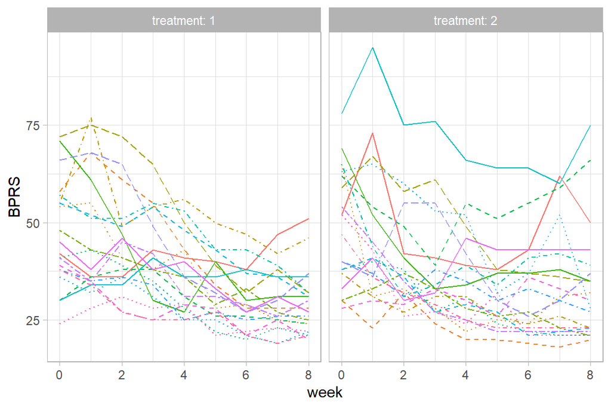

```r
# data is available in long format

# Plot the BPRS data
library(ggplot2)
ggplot(BPRSL, aes(x = week, y = BPRS, linetype = subject, col=subject)) +
  geom_line() +
  scale_linetype_manual(values = rep(1:10, times=4)) +
  facet_grid(. ~ treatment, labeller = label_both) +
  theme(legend.position = "none") +
  scale_y_continuous(limits = c(min(BPRSL$BPRS), max(BPRSL$BPRS)))
```

The first graph shows a lineplot of BPRS results of all individuals during the 8-week period grouped by the treatment group. It seems that most of the people have a decrease in BPRS during the 8 weeks. In the group 2 there is one person who has a higher score from the beginning.

However, if we want to show all individuals in the same plot, we need to do some data processing as subject have now labelled values from 1 to 20 in both groups. That’s a problem if plotting all men in one plot as each person should have unique subject code. (Or probably there is another way to deal with it but this one was the easiest for me..)

Though, I think that the plot combining both groups does not give any further information or value (it will be a bit chaotic with 40 different lines together…) I’ll next demonstrate how it can be done.

```r
# Subject is now factored but here I need it to be numeric
BPRSLplot <- BPRSL %>%
  mutate(subject = as.numeric(subject))

# Filtering people in the group 2 and changing the values of subject from 21 to 40
BPRSL2 <- BPRSLplot %>%
  filter(treatment == 2) %>%
  mutate(subject = subject +20)

# Saving the people in group 1
BPRSL1 <- BPRSLplot %>%
  filter(treatment == 1)

# Joining these two datasets with original group 1 and modified group 2, arranging by the week
BPRSL_new <- dplyr::full_join(BPRSL1, BPRSL2) %>%
  arrange(week)
# For plotting it's better to have subject as a factor
BPRSL_new <- BPRSL_new %>%
  mutate(subject = factor(subject))
# check the data
glimpse(BPRSL_new)
```

```
## Rows: 360
## Columns: 5
## $ treatment <fct> 1, 1, 1, 1, 1, 1, 1, 1, 1, 1, 1, 1, 1, 1, 1, 1, 1, 1, 1, 1, …
## $ subject   <fct> 1, 2, 3, 4, 5, 6, 7, 8, 9, 10, 11, 12, 13, 14, 15, 16, 17, 1…
## $ weeks     <chr> "week0", "week0", "week0", "week0", "week0", "week0", "week0…
## $ BPRS      <dbl> 42, 58, 54, 55, 72, 48, 71, 30, 41, 57, 30, 55, 36, 38, 66, …
## $ week      <dbl> 0, 0, 0, 0, 0, 0, 0, 0, 0, 0, 0, 0, 0, 0, 0, 0, 0, 0, 0, 0, …
```

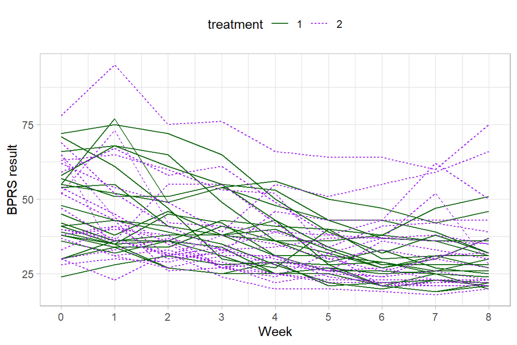

```r
# plotting, using some colors to show the treatment group
ggplot(BPRSL_new, aes(x = week, y = BPRS, group = subject, col=treatment)) +
  geom_line(aes(linetype = treatment)) +
  scale_color_manual(values=c("darkgreen", "purple"))+
  scale_x_continuous(name = "Week", breaks = seq(0, 8, 1)) +
  scale_y_continuous(name = "BPRS result") +
  theme(legend.position = "top")
```

This plot suggest that overall the data is quite homogeneous, maybe that one person with higher values. There might be an overall trend of slightly decreasing values of BPRS during the 8-week period. There are no notable differences (based on this visual interpretation) between the groups.

### Analysis & modelling

#### The Linear model

Continuing to ignore the repeated-measures structure of the data, I next fit a multiple linear regression model with BPRS as response and `week` and `treatment` as explanatory variables.

```r
# Working with the "original" long format data: BPRSL
# create a regression model
BPRS_reg <- lm(BPRS ~week + treatment, data = BPRSL)

# print the summary of the model
summary(BPRS_reg)
```

```
##
## Call:
## lm(formula = BPRS ~ week + treatment, data = BPRSL)
##
## Residuals:
##     Min      1Q  Median      3Q     Max
## -22.454  -8.965  -3.196   7.002  50.244
##
## Coefficients:
##             Estimate Std. Error t value Pr(>|t|)
## (Intercept)  46.4539     1.3670  33.982   <2e-16 ***
## week         -2.2704     0.2524  -8.995   <2e-16 ***
## treatment2    0.5722     1.3034   0.439    0.661
## ---
## Signif. codes:  0 '***' 0.001 '**' 0.01 '*' 0.05 '.' 0.1 ' ' 1
##
## Residual standard error: 12.37 on 357 degrees of freedom
## Multiple R-squared:  0.1851, Adjusted R-squared:  0.1806
## F-statistic: 40.55 on 2 and 357 DF,  p-value: < 2.2e-16
```

The model summary states that the estimated mean of BPRS at the baseline (week = 0) and without group allocation would be 46.5. Time/week is negatively and significantly correlated to the BPRS meaning that people will have 2.2 unit lower scores after each week. Treatment group 2 is positively correlated with BPRS suggesting that men in this group have higher BPR scores but this is not statistically significant.

R squared and adj. R squared are around 0.18 meaning that app. 18 % of the variation seen in BPRS results can be explained by the week/time point and treatment group.

#### The Random Intercept Model

*The previous model assumes independence of the repeated measures of BPRS which is very unlikely as the results are from the same individuals. So, let’s consider some more appropriate models. I will use the `lme4` package which offers efficient tools for fitting linear and generalized linear mixed-effects models.*

```r
# access library lme4
library(lme4)
# Create a random intercept model: MODEL 1
BPRS_ref <- lmer(BPRS ~ week + treatment + (1 | subject), data = BPRSL, REML = FALSE)

# print the summary of the model
summary(BPRS_ref)
```

```
## Linear mixed model fit by maximum likelihood  ['lmerMod']
## Formula: BPRS ~ week + treatment + (1 | subject)
##    Data: BPRSL
##
##      AIC      BIC   logLik deviance df.resid
##   2748.7   2768.1  -1369.4   2738.7      355
##
## Scaled residuals:
##     Min      1Q  Median      3Q     Max
## -3.0481 -0.6749 -0.1361  0.4813  3.4855
##
## Random effects:
##  Groups   Name        Variance Std.Dev.
##  subject  (Intercept)  47.41    6.885
##  Residual             104.21   10.208
## Number of obs: 360, groups:  subject, 20
##
## Fixed effects:
##             Estimate Std. Error t value
## (Intercept)  46.4539     1.9090  24.334
## week         -2.2704     0.2084 -10.896
## treatment2    0.5722     1.0761   0.532
##
## Correlation of Fixed Effects:
##            (Intr) week
## week       -0.437
## treatment2 -0.282  0.000
```

*Read interpretation below the summary table*

#### Random Intercept and Random Slope Model

```r
# create a random intercept and random slope model: MODEL 2
library(lme4)
BPRS_ref2 <- lmer(BPRS ~ week + treatment + (week | subject), data = BPRSL, REML = FALSE)

# print the summary of the model,will be printed a bit later
# summary(BPRS_ref2)

# perform an ANOVA test on the two models
anova(BPRS_ref2, BPRS_ref)
```

|  | npar | AIC | BIC | logLik | deviance | Chisq | Df | Pr(>Chisq) |
| --- | --- | --- | --- | --- | --- | --- | --- | --- |
| BPRS_ref | 5 | 2748.712 | 2768.143 | -1369.356 | 2738.712 | NA | NA | NA |
| BPRS_ref2 | 7 | 2745.440 | 2772.643 | -1365.720 | 2731.440 | 7.272058 | 2 | 0.0263568 |

Anova results show the Chi-squared value 7.2 and p-value 0.026 meaning these two models are significantly different.

#### Random Intercept and Random Slope Model with interaction

Finally, I’ll fit a random intercept and slope model that allows for a treatment × week interaction.

```r
# create a random intercept and random slope model with the interaction: MODEL 3
library(lme4)
BPRS_ref3 <- lmer(BPRS ~ week + treatment + (week*treatment | subject), data = BPRSL, REML = FALSE)

# print the summary of the model
# summary(BPRS_ref3)

# print all three summaries using modelsummary package (refs, ref2s and ref3s)
library(modelsummary)
models <- list(
  "BPRS_ref" <- lmer(BPRS ~ week + treatment + (1 | subject), data = BPRSL, REML = FALSE),
  "BPRS_ref2" <- lmer(BPRS ~ week + treatment + (week | subject), data = BPRSL, REML = FALSE),
  "BPRS_ref3" <- lmer(BPRS ~ week + treatment + (week*treatment | subject), data = BPRSL, REML = FALSE))

modelsummary(models, output = "html", statistic = c("conf.int", "p = {p.value}"))
```

|  | (1) | (2) | (3) |
| --- | --- | --- | --- |
| (Intercept) | 46.454 | 46.454 | 44.947 |
|  | [42.700, 50.208] | [42.314, 50.594] | [40.263, 49.631] |
|  | p = <0.001 | p = <0.001 | p = <0.001 |
| week | −2.270 | −2.270 | −2.181 |
|  | [−2.680, −1.861] | [−2.856, −1.685] | [−2.756, −1.606] |
|  | p = <0.001 | p = <0.001 | p = <0.001 |
| treatment2 | 0.572 | 0.572 | 2.973 |
|  | [−1.544, 2.688] | [−1.474, 2.619] | [−2.485, 8.430] |
|  | p = 0.595 | p = 0.583 | p = 0.285 |
| SD (Intercept subject) | 6.885 | 8.051 | 13.358 |
| SD (week subject) |  | 0.980 | 1.710 |
| Cor (Intercept~week subject) |  | −0.513 | −0.862 |
| SD (treatment2 subject) |  |  | 19.477 |
| SD (week × treatment2) |  |  | 1.859 |
| Cor (Intercept~treatment2 subject) |  |  | −0.757 |
| Cor (Intercept~week × treatment2) |  |  | 0.675 |
| Cor (week~treatment2 subject) |  |  | 0.756 |
| Cor (week~week × treatment2) |  |  | −0.728 |
| Cor (treatment2~week × treatment2) |  |  | −0.815 |
| SD (Observations) | 10.208 | 9.871 | 6.062 |
| Num.Obs. | 360 | 360 | 360 |
| R2 Marg. | 0.186 | 0.186 | 0.135 |
| R2 Cond. | 0.440 | 0.477 | 0.854 |
| AIC | 2745.2 | 2741.3 | 2520.0 |
| BIC | 2764.6 | 2768.5 | 2574.5 |
| ICC | 0.3 | 0.4 | 0.8 |
| RMSE | 9.95 | 9.47 | 5.48 |

```r
# perform an ANOVA test on the two models
anova(BPRS_ref3, BPRS_ref2)
```

|  | npar | AIC | BIC | logLik | deviance | Chisq | Df | Pr(>Chisq) |
| --- | --- | --- | --- | --- | --- | --- | --- | --- |
| BPRS_ref2 | 7 | 2745.44 | 2772.643 | -1365.720 | 2731.44 | NA | NA | NA |
| BPRS_ref3 | 14 | 2525.81 | 2580.215 | -1248.905 | 2497.81 | 233.6307 | 7 | 0 |

Anova results again show that the model 3 and model 2 are significantly different. Chi-squared value is 233,63, which is even much larger compared to the model2 vs. model 1 comparison.

So, how well do these models fit our data?

In the summary table, we can see two R2 values: The marginal R2 (R2 Marg) and conditional R2 (R2 Cond.). TR2 Marg. considers only the variance of the fixed effects, while the conditional R2 takes both the fixed and random effects into account (i.e., the total model). The model 1 and 2 have cond. R2 values of 0.44-0.47 meaning that the models are not very accurate. However, the model 3 seems to have the best performance as the cond. R2 is 0.85 (the model would have a perfect fit with value 1). We can also see, that the model 3 has lowest BIC and AIC reflecting the better fit compared to the other models.

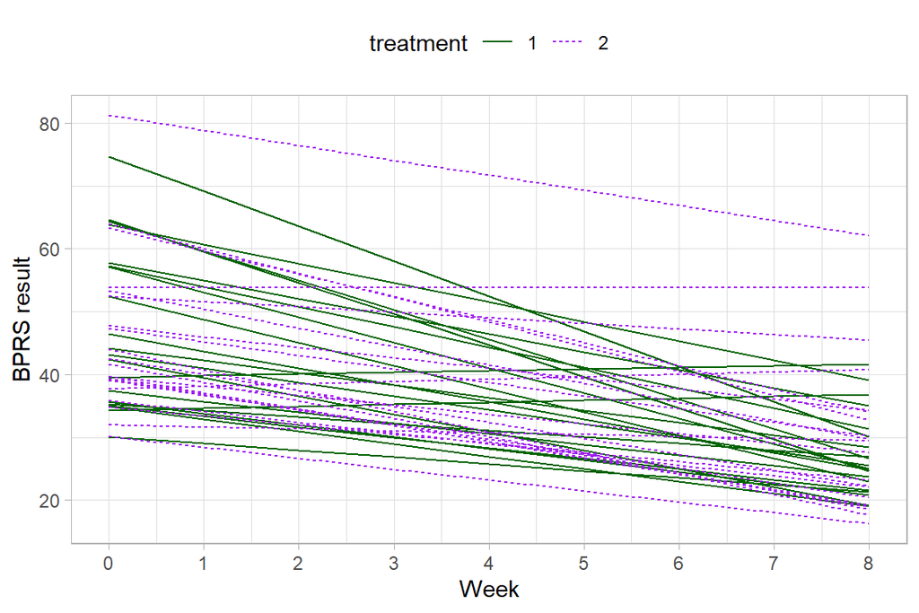

```r
# Here I use the BPRSL_new data for plotting where each subject has a unique subject ID value
# Create a vector of the fitted values
Fitted <- fitted(BPRS_ref3)

library(dplyr)
library(tidyr)

# Create a new column fitted to
BPRSL_new <- mutate(BPRSL_new, Fitted)

# draw the plot of BPRSL with the Fitted BPRS values
library(ggplot2)
ggplot(BPRSL_new, aes(x = week, y = Fitted, group = subject, col=treatment)) +
  geom_line(aes(linetype = treatment)) +
  scale_color_manual(values=c("darkgreen", "purple"))+
  scale_x_continuous(name = "Week", breaks = seq(0, 8, 1)) +
  scale_y_continuous(name = "BPRS result") +
  theme(legend.position = "top")
```

The lineplot using the fitted BPRS values shows more clearly the decreasing trend in BPRS results during the 8 weeks. Thus, it seems that the intervention was somehow helpful in decreasing the level of symptoms (statistically).

> Thanks for joining in my IODS journey!

**THE END**